# Презентация по лабораторной работе №5

## Задания лабораторной работы

Разнообразные варианты представления данных(рис. 30).

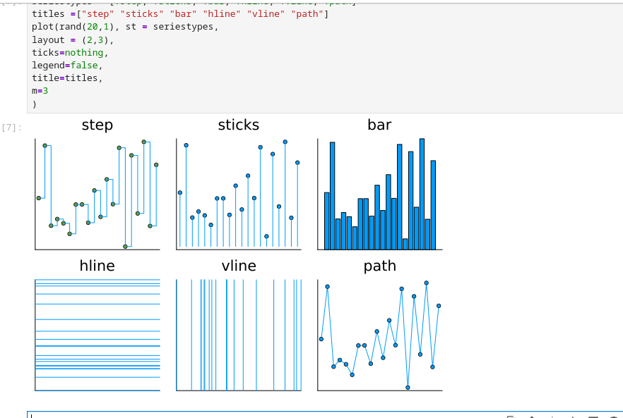

Рисунок 30: Варианты представления данных

## Задания лабораторной работы

Демонстрация применения сложного макета для построения графиков(рис. 31).

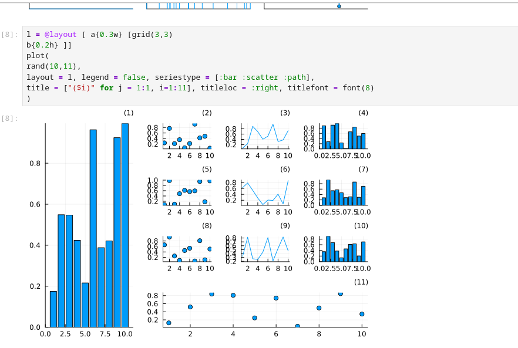

Рисунок 31: Сложный макет

## Задания самостоятельной работы

все возможные типы графиков (простые, точечные, гистограммы и т.д.) функции 𝑦 = sin(𝑥)(рис. 32).

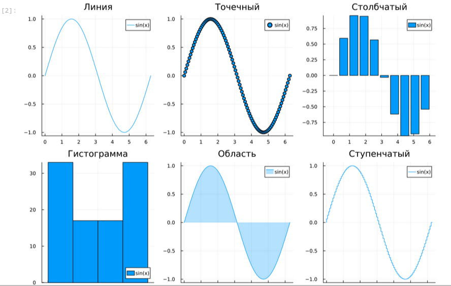

Рисунок 32: №1

## Задания самостоятельной работы

графики функции 𝑦 = sin(𝑥), 𝑥 = 0, 2𝜋 со всеми возможными типами оформления линий графика (рис. 33).

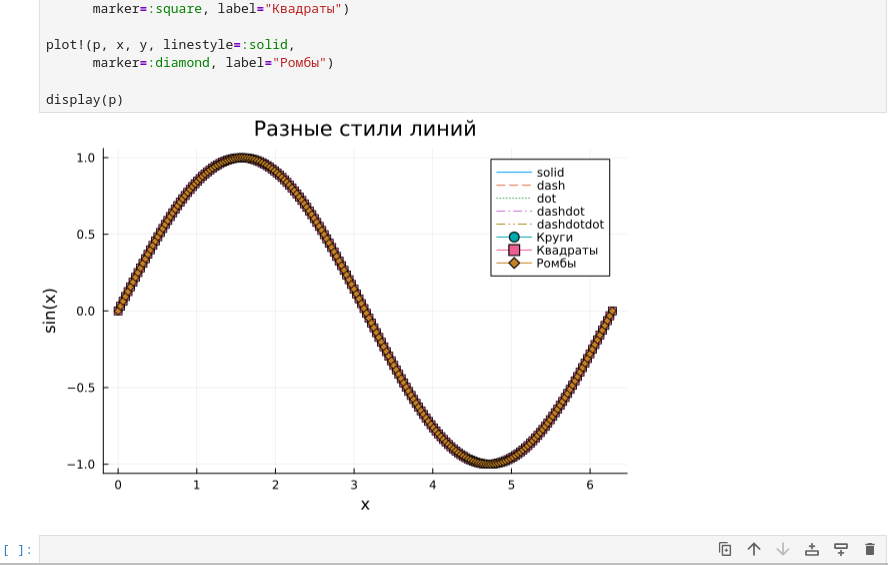

Рисунок 33: №2

## Задания самостоятельной работы

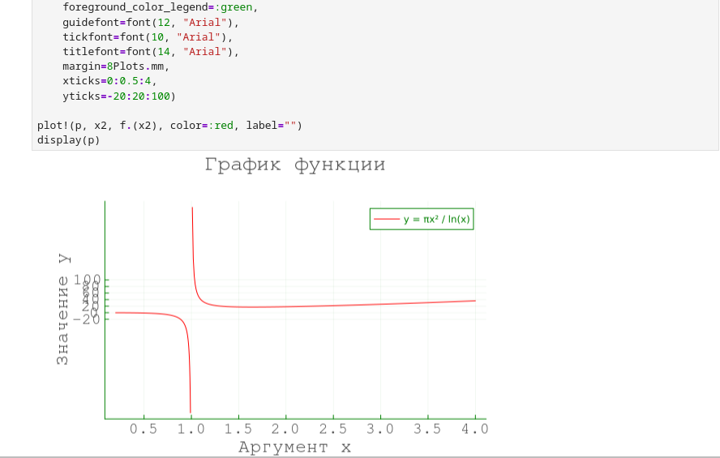

Рисунок 34: №3

## Задания самостоятельной работы

(рис. 35).

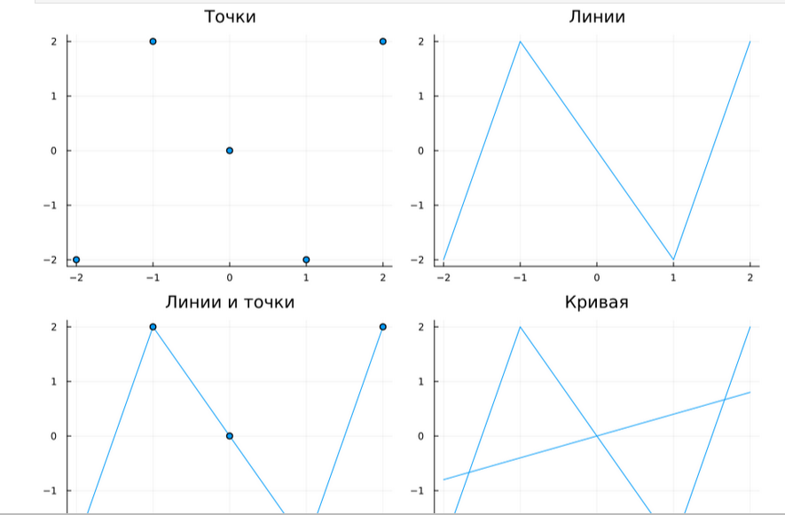

Рисунок 35: №4

## Задания самостоятельной работы

Строю два графика функций по заданию (рис. 36).

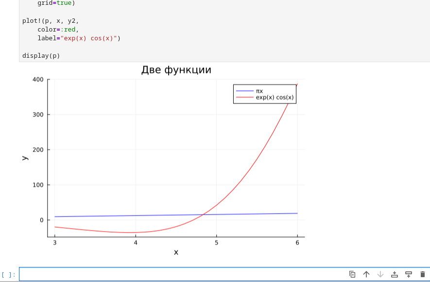

Рисунок 36: №5

## Задания самостоятельной работы

Строю график некоторых экспериментальных данных, учитывая ошибку измерения (рис. 37).

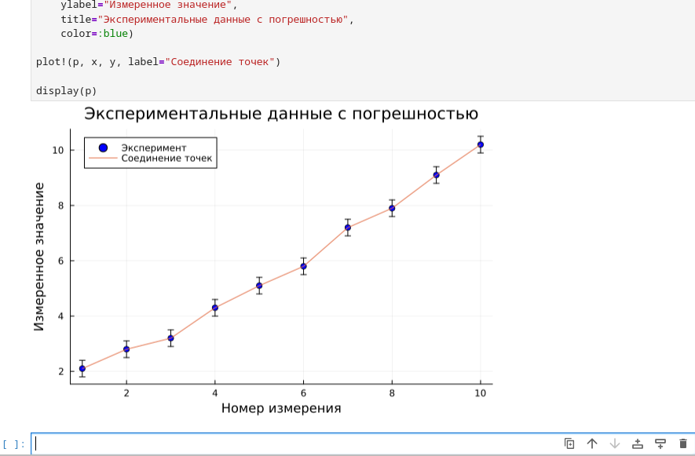

Рисунок 37: №6

## Задания самостоятельной работы

Строю точечный график случайных данных (рис. 38).

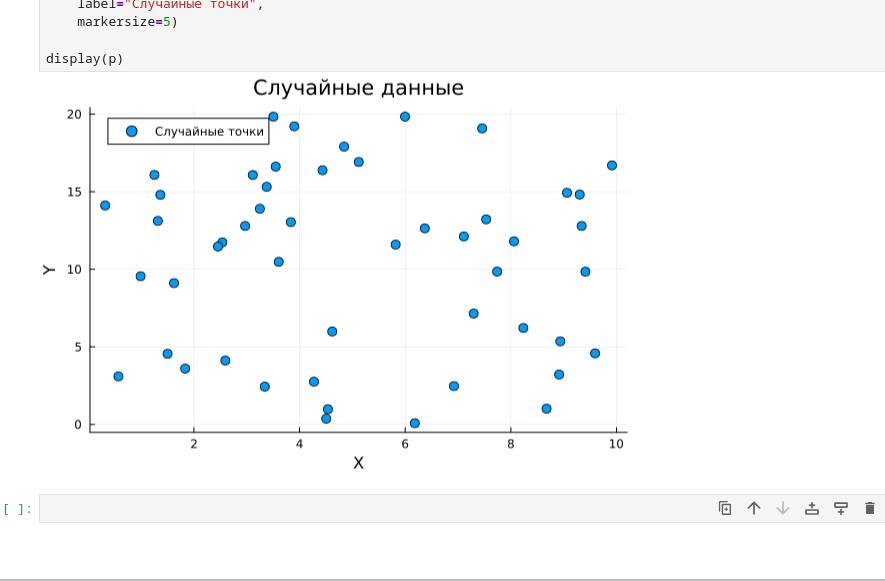

Рисунок 38: №7

## Задания самостоятельной работы

Строю 3-мерный точечный график случайных данных (рис. 39).

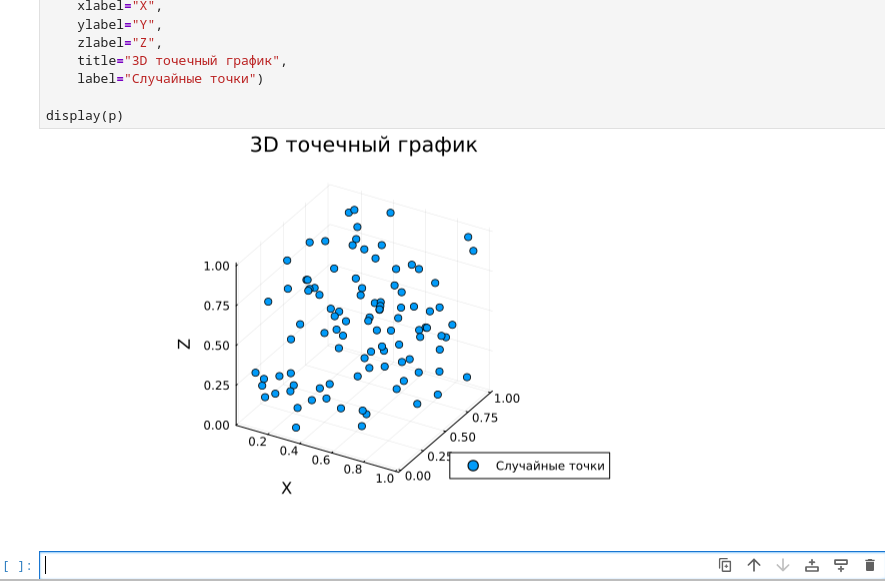

Рисунок 39: №8

## Задания самостоятельной работы

Создаю анимацию с построением синусоиды (рис. 40).

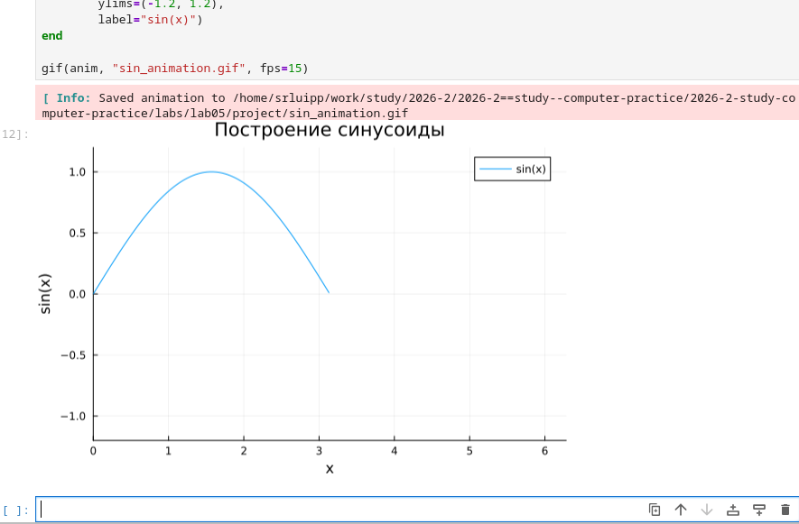

Рисунок 40: №9

## Задания самостоятельной работы

Строю анимированную гипоциклоиду для 2 целых значений модуля 𝑘 и 2 рациональных значений модуля 𝑘 (рис. 41).

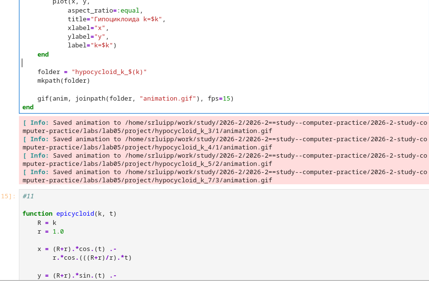

Рисунок 41: №10

## Задания самостоятельной работы

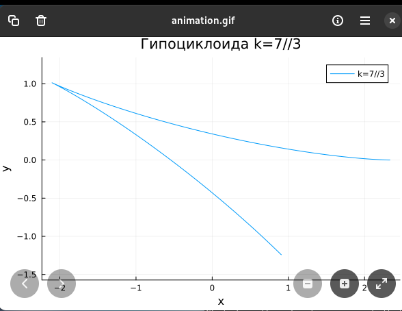

# Выводы

В ходе лабораторной работы я научилась строить графики в Jupyter Lab на языке Julia